Let us consider the dataframe `house`, which includes information about the price, the size, the floor, the number of bedrooms (bed) and the number of bathrooms (bath) of 546 houses. The output of the str command is given below

```
## 'data.frame':    546 obs. of  5 variables:
##  $ price: num  42000 38500 49500 60500 61000 66000 66000 69000 83800 88500 ...
##  $ size : int  5850 4000 3060 6650 6360 4160 3880 4160 4800 5500 ...
##  $ bed  : int  3 2 3 3 2 3 3 3 3 3 ...
##  $ bath : int  1 1 1 1 1 1 2 1 1 2 ...
##  $ floor: int  2 1 1 2 1 1 2 3 1 4 ...
```

A suitable linear regression model can be defined in order to study the potential relationship between the price, which is the response variable, and the explanatory variables considered in the dataframe. Describe how to perform a preliminary data analysis on this dataframe, using suitable R commands. Moreover, consider the following plots and discuss the possibility of measuring the variables price and size in the logarithmic scale.

### Distribuzione delle variabili

```r
source("./../functions.R", local = knitr::knit_global())

summary(house)
```

```
##      price             size            bed             bath
##  Min.   : 25000   Min.   : 1650   Min.   :1.000   Min.   :1.000
##  1st Qu.: 49125   1st Qu.: 3600   1st Qu.:2.000   1st Qu.:1.000
##  Median : 62000   Median : 4600   Median :3.000   Median :1.000
##  Mean   : 68122   Mean   : 5150   Mean   :2.965   Mean   :1.286
##  3rd Qu.: 82000   3rd Qu.: 6360   3rd Qu.:3.000   3rd Qu.:2.000
##  Max.   :190000   Max.   :16200   Max.   :6.000   Max.   :4.000
##      floor
##  Min.   :1.000
##  1st Qu.:1.000
##  Median :2.000
##  Mean   :1.808
##  3rd Qu.:2.000
##  Max.   :4.000
```

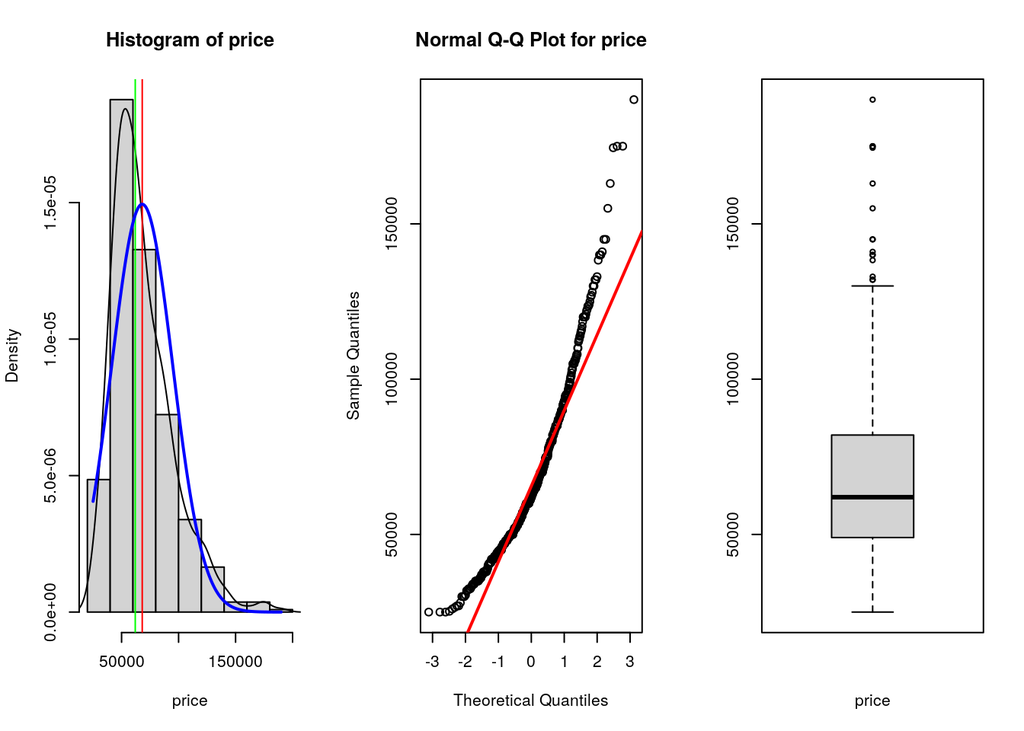

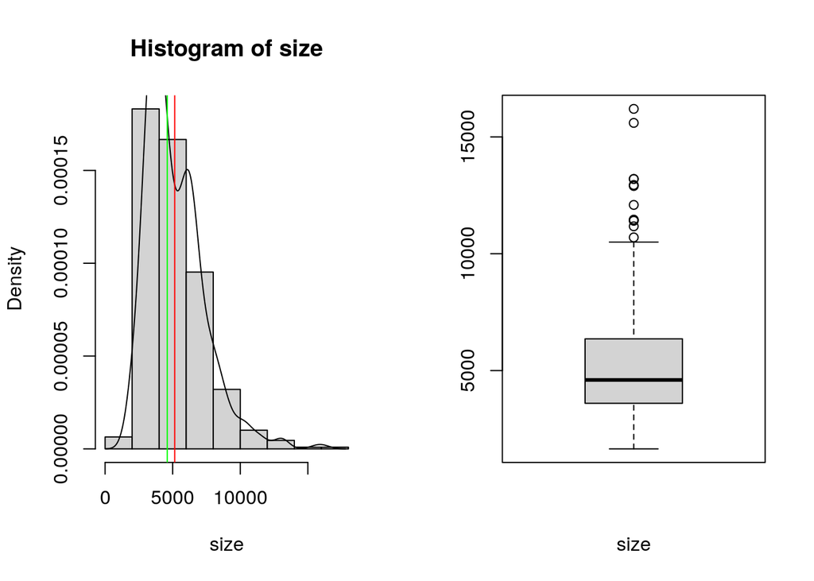

```
## [1] "Skewness indexes"
##    price     size
## 1.206503 1.319121
## [1] "Kurtosis indexes - 3"
##    price     size
## 1.930871 2.726370
```

```r
numeric.graph(house, 1:2, normality.check = 1)
```

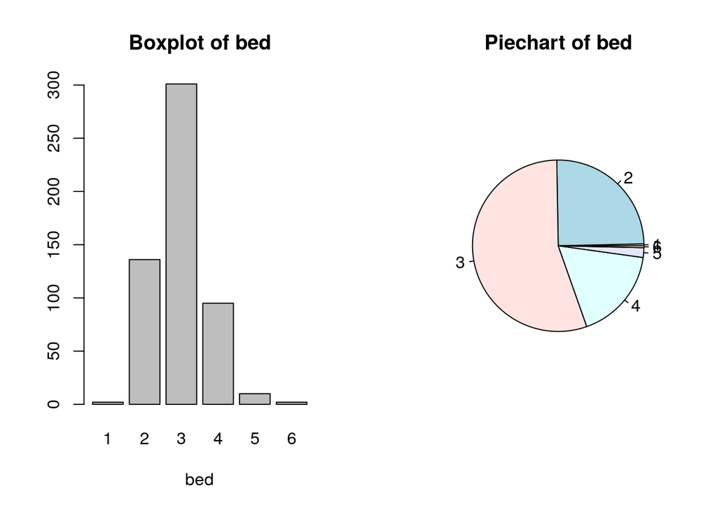

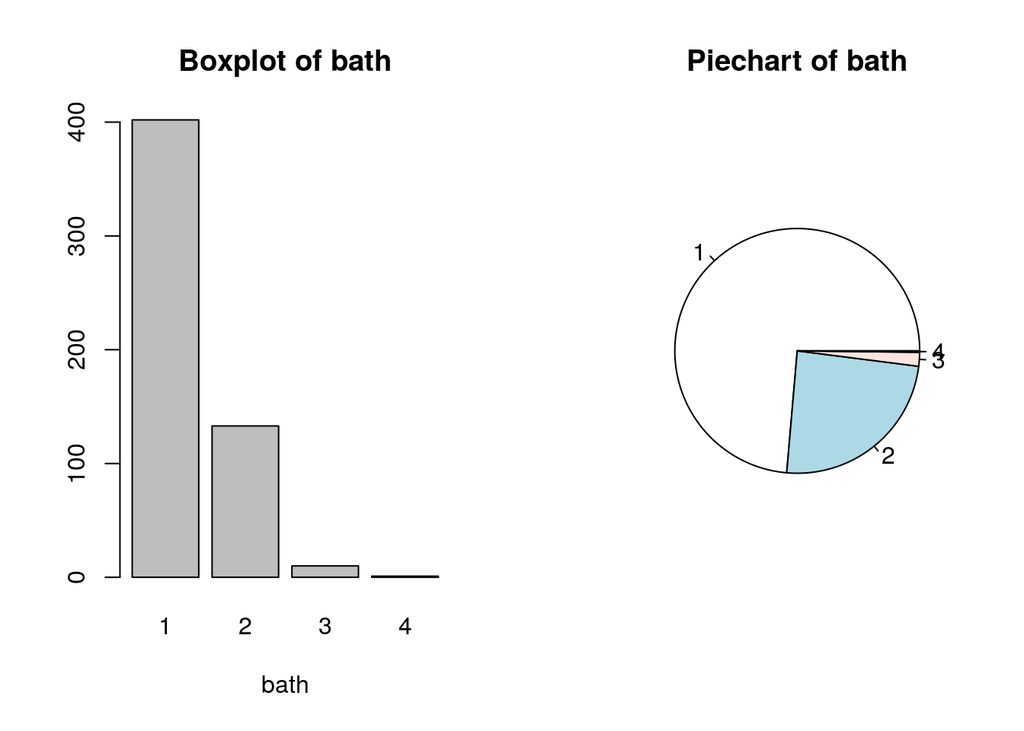

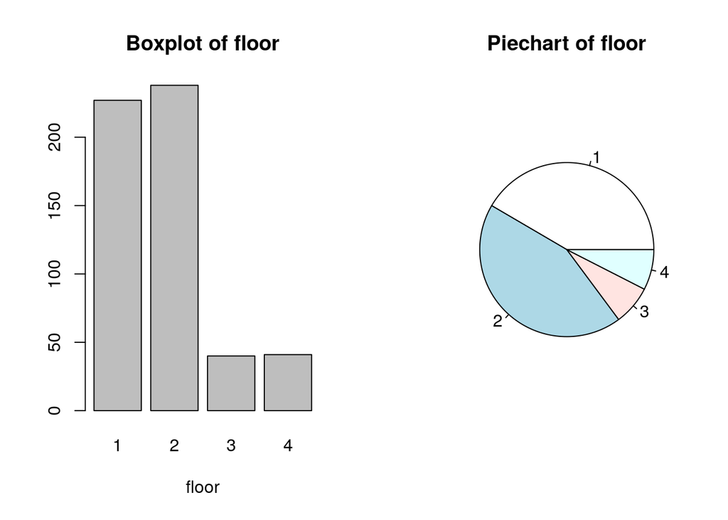

```r
categorical.graph(house, 3:5)
```

#### Osservazioni

- la variabile risposta `price` ha una curva a campana ipernormale asimmetrica a destra, con code molto pesanti (soprattutto a destra dove si concentrano un buon numero di outliers), per cui eventuali ipotesi di normalità sono violate (com’è visibile anche dal qq-plot). Si consiglia una trasformata per rientrare nelle ipotesi di normalità.
- anche `size` presenta un andamento molto simile a quello di `price`
- `bed`, invece presenta una distribuzione dei valori che sembra ricordare molto quelli di una normale. Per conferma calcoliamo simmetria e kurtosi:

```r
moments::kurtosis(house$bed) - 3
```

```
## [1] 0.7172758
```

```r
moments::skewness(house$bed)
```

```
## [1] 0.4945091
```

```
Entrambi i valori sono vicini allo 0, confermando l'ipotesi di normalità
```

- Dal grafico di `bath` si nota come grandissima parte delle case (ca. 3/4 del dataset) ha un bagno, mentre pochissime casi hanno più di due bagni. L’andamento ricorda quello di una distribuzione geometrica.
- Considerazioni simili valgono anche per `floor`, la maggior parte delle case analizzate ha uno o due piani (più o meno lo stesso numero), solo una minima parte ne ha di più. L’andamento non sembra seguire particolari distribuzioni.

### Relazioni tra variabili

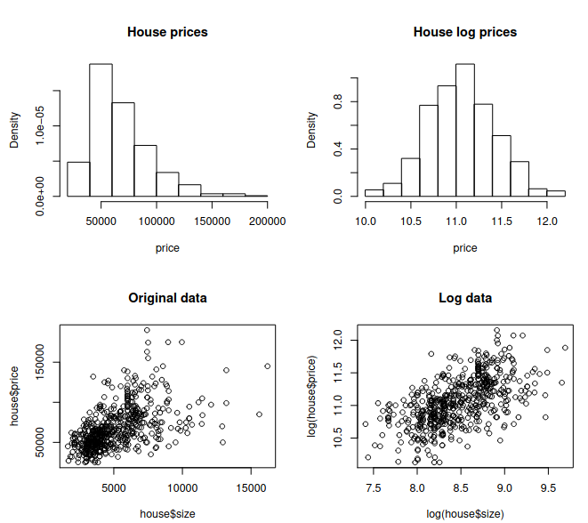

La trasformazione logaritmica sembra l’ideale per rientrare sia nell’ipotesi di normalità della variabile risposta, sia per quanto riguarda la linearità della correlazione tra le due.

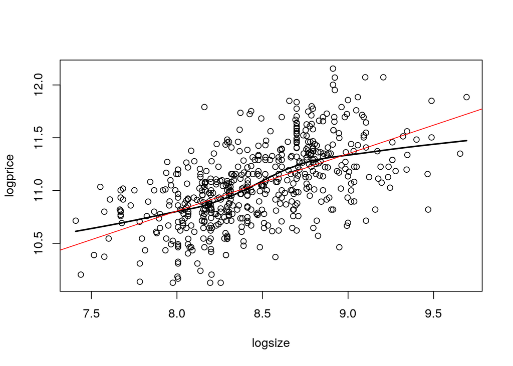

```r
house$logprice <- log(house$price)
house$logsize <- log(house$size)
scatterplots.graph(6, 7, house)
```

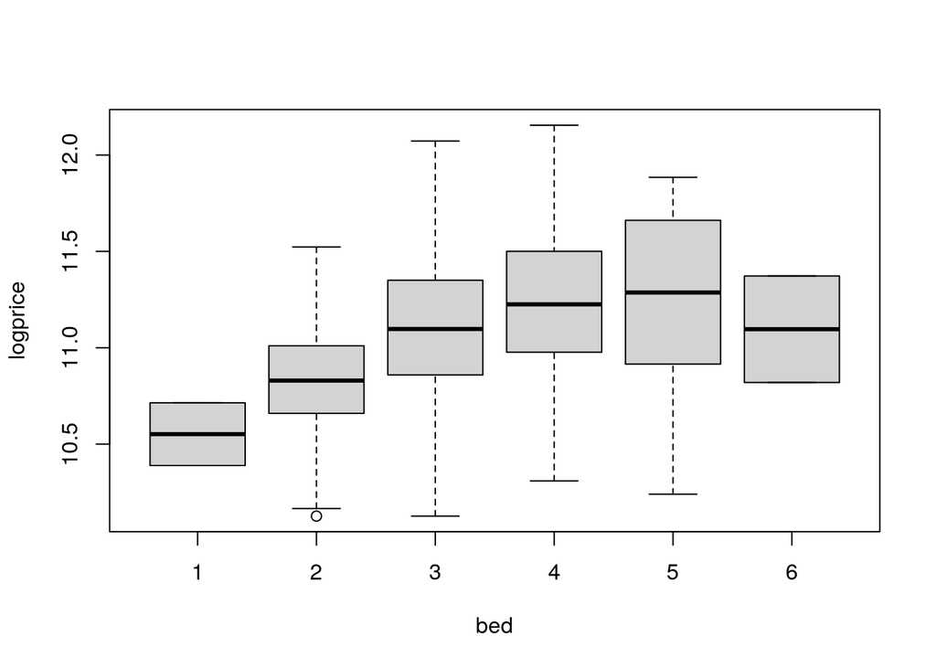

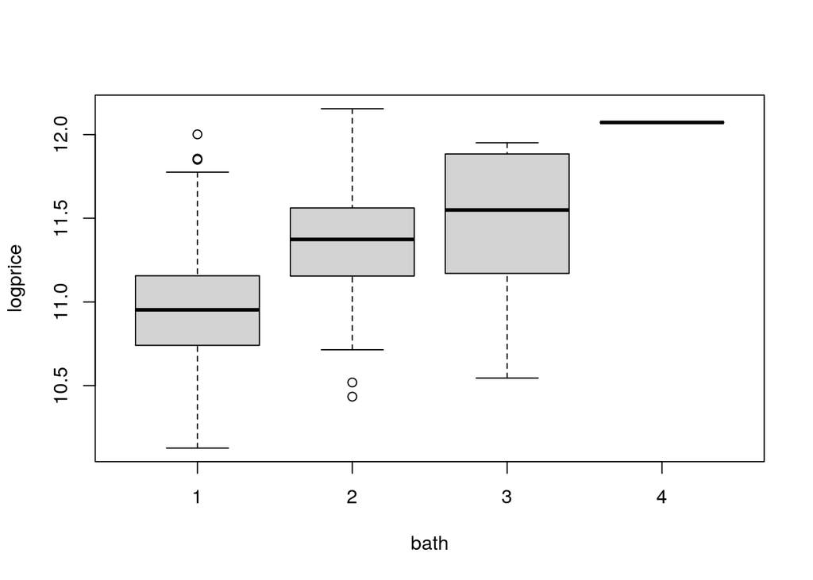

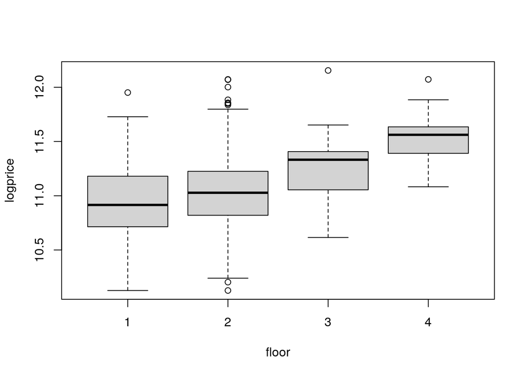

```r
boxplots.graph(6, 3:5, house)
```

#### Osservazioni

- Il logaritmo del price e quello della dimensione delle case sembrano essere correlati linearmemente.
- Sembra esserci una correlazione tra il numero di bagni, i piani e il prezzo. Tuttavia, a rigor di logica, potrebbe essere interessante indagare correlazioni tra il numero di bagni e i piani della casa:

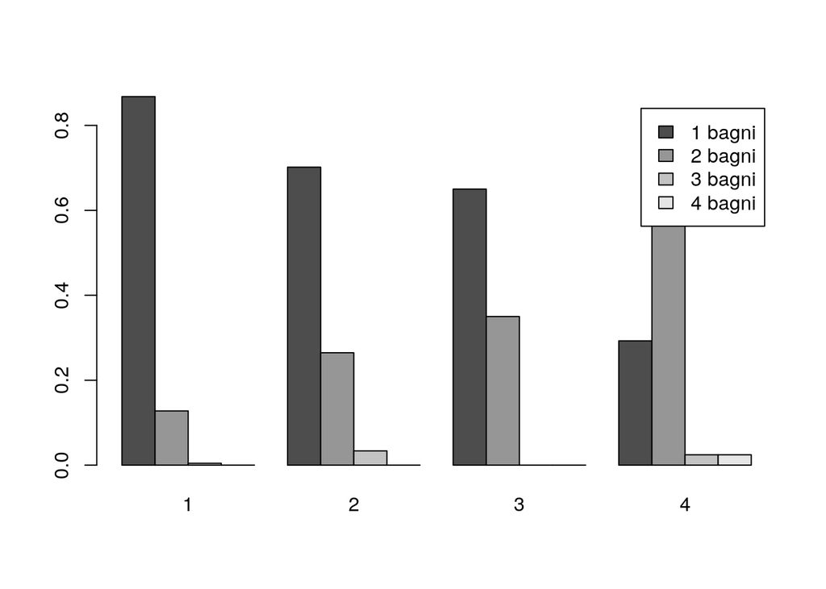

```r
tab <- table(house$bath, house$floor)
barplot(prop.table(tab,2), beside=T, legend.text = paste(colnames(tab), "bagni"))
```

Sembra esserci una correlazione tra il numero di bagni e il numero di piani di una casa, in particolare maggiore è il numero di piani più aumenta la probabilità di avere 2 o più bagni in casa.

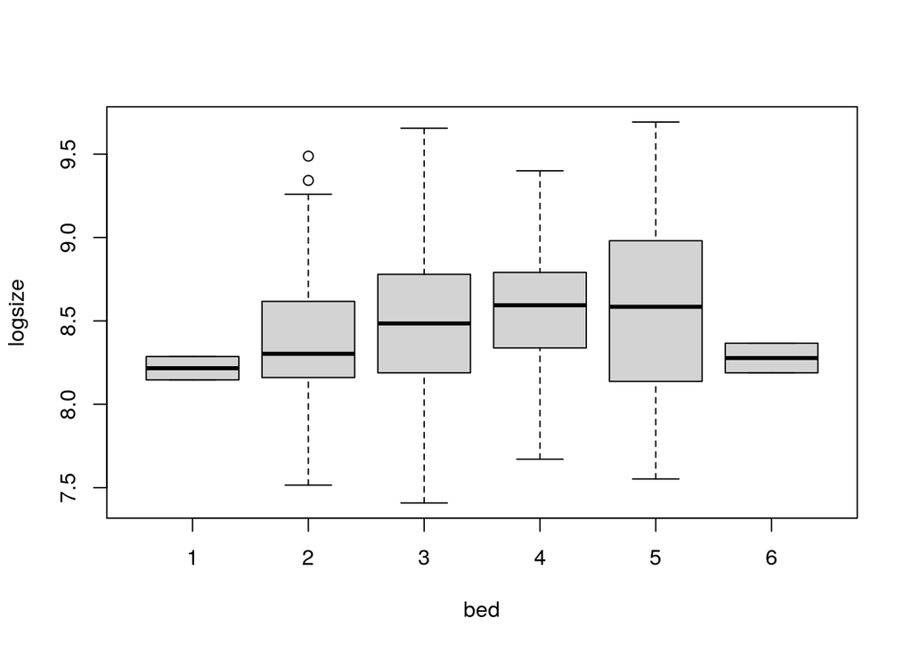

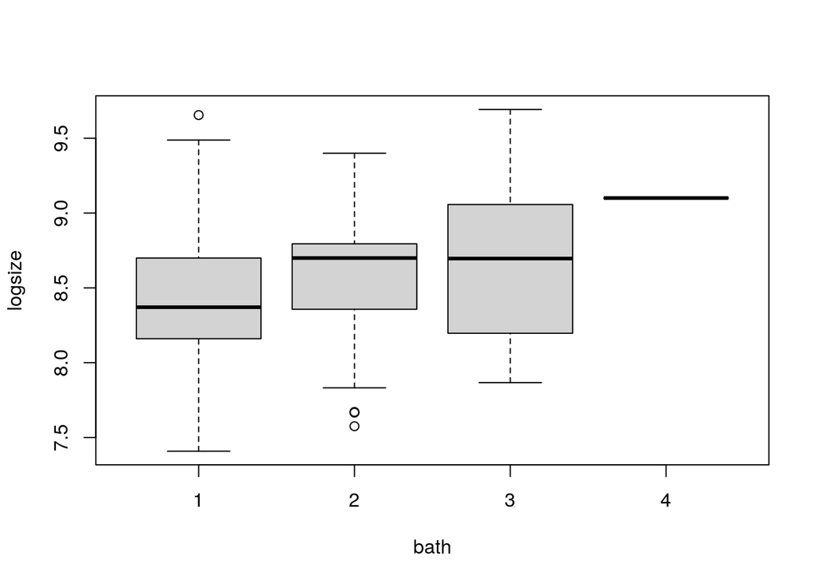

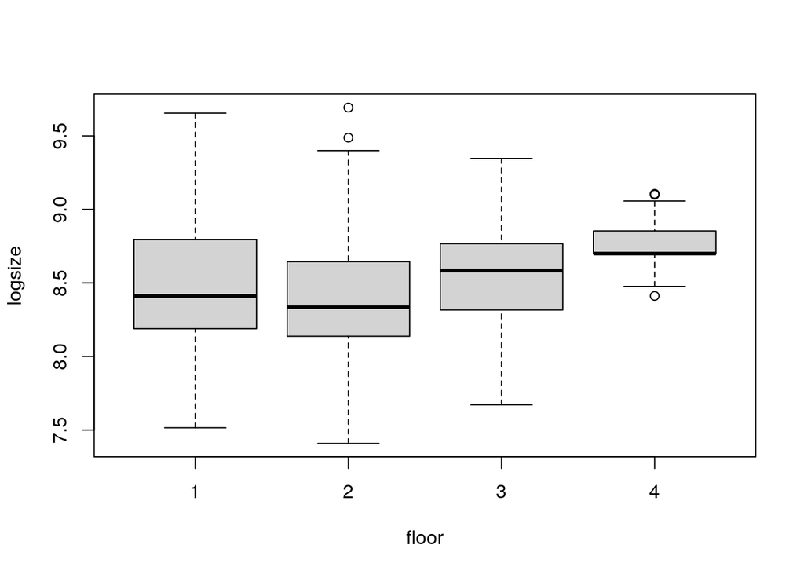

```r
boxplots.graph(7, 3:5, data = house)
```

Sembrano esserci correlazioni tra logsize le altre variabili, tuttavia viste le distribuzioni di queste variabili nel dataset (tante osservazioni concentrate su pochi valori), c’è il rischio che queste osservazioni siano poco attendibili e dovute più alla struttura del campione che alla popolazione in esame.

After fitting the regression model `fit <- lm(log(price) ∼ log(size) + bed + bath + floor, data=house)`, the following outputs are obtained by the R commands `summary(fit)` and `plot(fit)`, respectively.

```
##
## Call:
## lm(formula = log(price) ~ log(size) + bed + bath + floor, data = house)
##
## Residuals:
##      Min       1Q   Median       3Q      Max
## -0.80006 -0.16043  0.01391  0.16359  0.75723
##
## Coefficients:
##             Estimate Std. Error t value Pr(>|t|)
## (Intercept)  6.63539    0.23052  28.785  < 2e-16 ***
## log(size)    0.45274    0.02770  16.344  < 2e-16 ***
## bed          0.04997    0.01668   2.995  0.00287 **
## bath         0.20265    0.02386   8.493  < 2e-16 ***
## floor        0.10052    0.01386   7.253 1.42e-12 ***
## ---
## Signif. codes:  0 '***' 0.001 '**' 0.01 '*' 0.05 '.' 0.1 ' ' 1
##
## Residual standard error: 0.2511 on 541 degrees of freedom
## Multiple R-squared:  0.5477, Adjusted R-squared:  0.5444
## F-statistic: 163.8 on 4 and 541 DF,  p-value: < 2.2e-16
```

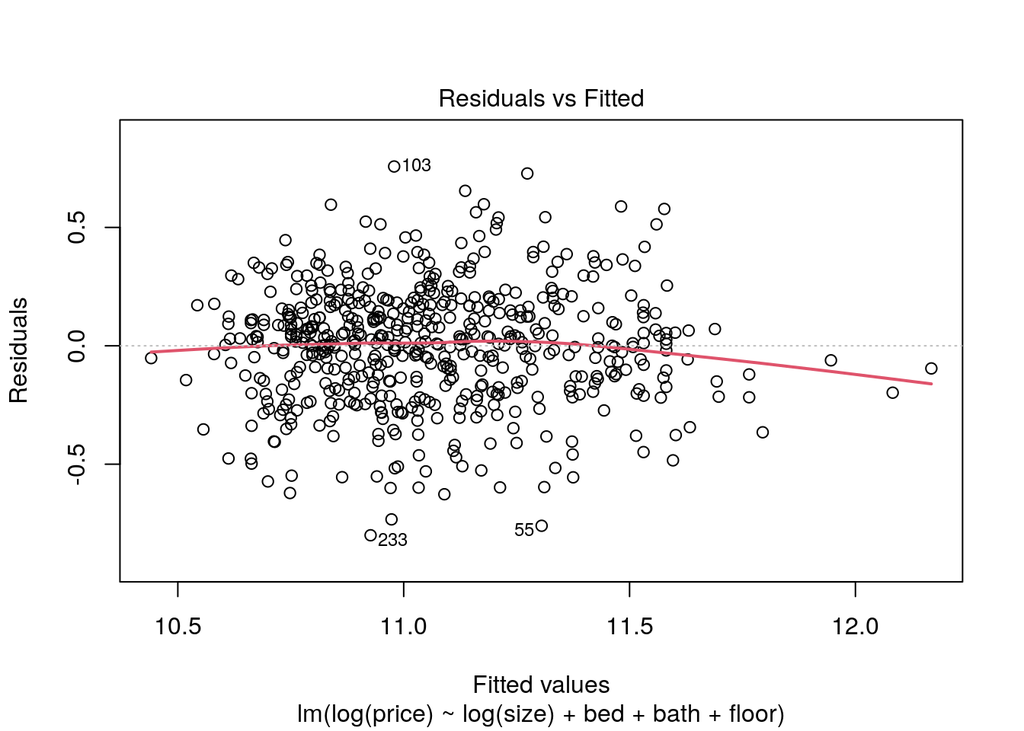

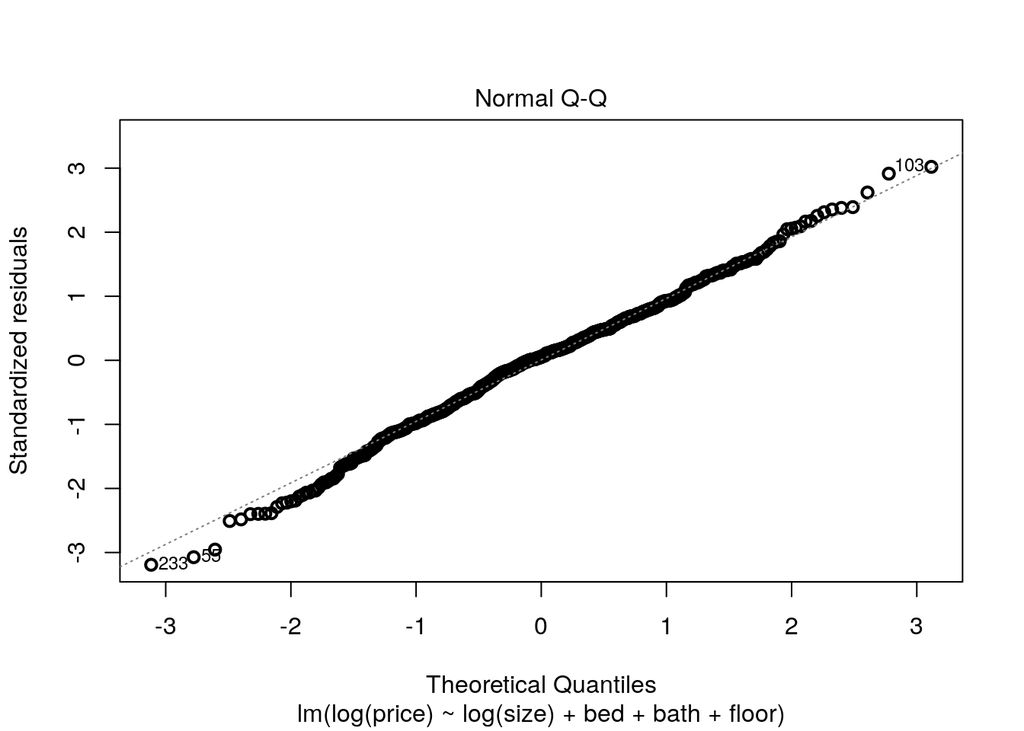

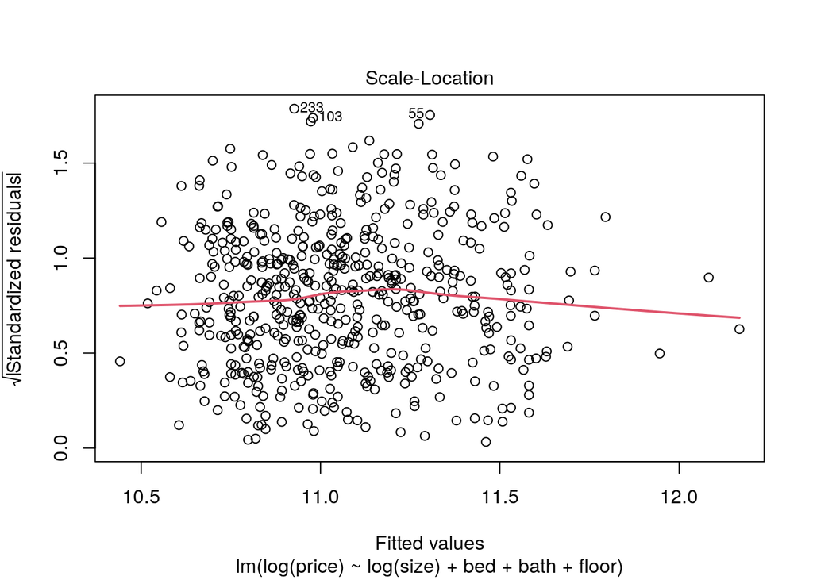

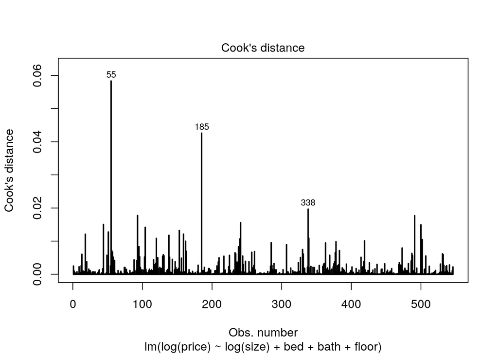

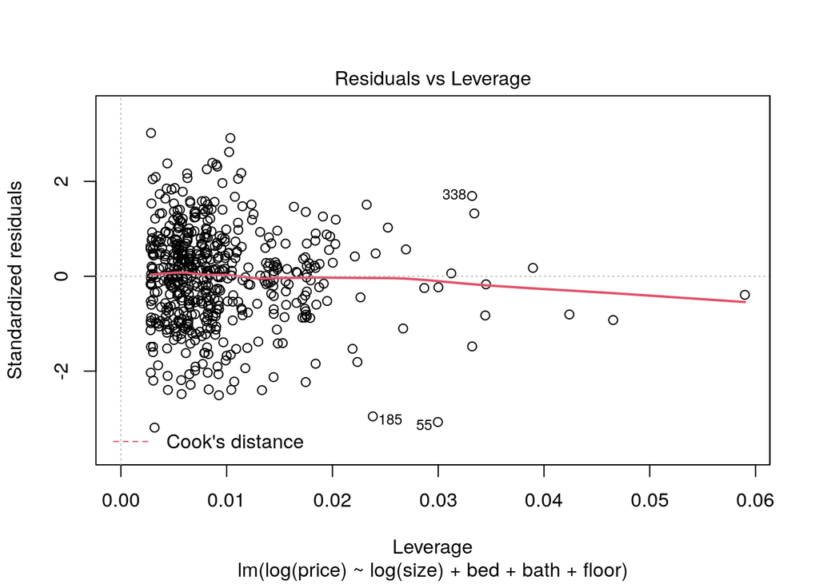

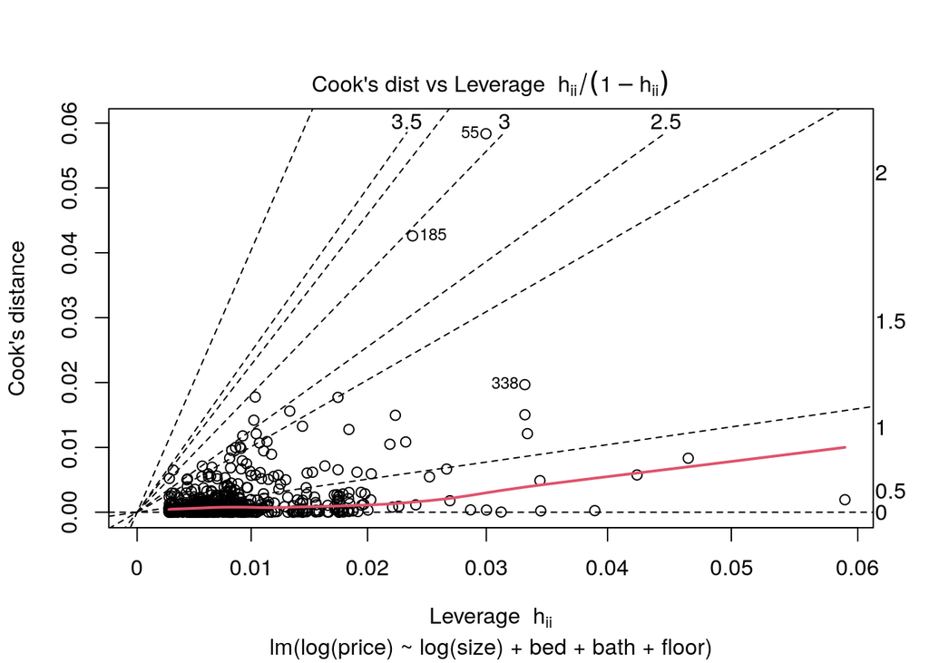

Describe how to interpret these results, and then suggest how to proceed with further analyses with particular regard to prediction.

#### Osservazioni

- Tutti i regressori indicato sono molto o moderatamente significativi (tutti i p-value dei regressori e quello del test F sono molto bassi)
- Il modello sembra rispettare le ipotesi di normalità dei residui e omoschedasticità.
- L’ipotesi di linearità non sembra presentare particolari criticità, come visibile dal grafico dei residui e dei residui standardizzati.
- Non ci sono punti influenti.
- Gli indici $R^2$ sono molto simili e con valore abbastanza basso, questo potrebbe rendere delle eventuali previsioni fatte utilizzando il modello poco affidabili. Questo probabilmente è dovuto sia all’elevata varianza di `price` che alla scarsità di dati per alcuni valori estremi dei regressori.

#### Modello alternativo

```r
fit2 <- lm(log(price) ~ log(size) + bed + bath + floor + floor:size, data=house)
summary(fit2)
```

```
##
## Call:
## lm(formula = log(price) ~ log(size) + bed + bath + floor + floor:size,
##     data = house)
##
## Residuals:
##      Min       1Q   Median       3Q      Max
## -0.81200 -0.16323  0.01397  0.15803  0.74409
##
## Coefficients:
##               Estimate Std. Error t value Pr(>|t|)
## (Intercept)  5.511e+00  5.197e-01  10.604  < 2e-16 ***
## log(size)    5.837e-01  6.093e-02   9.580  < 2e-16 ***
## bed          4.601e-02  1.669e-02   2.757  0.00604 **
## bath         2.125e-01  2.410e-02   8.816  < 2e-16 ***
## floor        1.858e-01  3.795e-02   4.895  1.3e-06 ***
## floor:size  -1.477e-05  6.127e-06  -2.411  0.01624 *
## ---
## Signif. codes:  0 '***' 0.001 '**' 0.01 '*' 0.05 '.' 0.1 ' ' 1
##
## Residual standard error: 0.25 on 540 degrees of freedom
## Multiple R-squared:  0.5525, Adjusted R-squared:  0.5484
## F-statistic: 133.4 on 5 and 540 DF,  p-value: < 2.2e-16
```

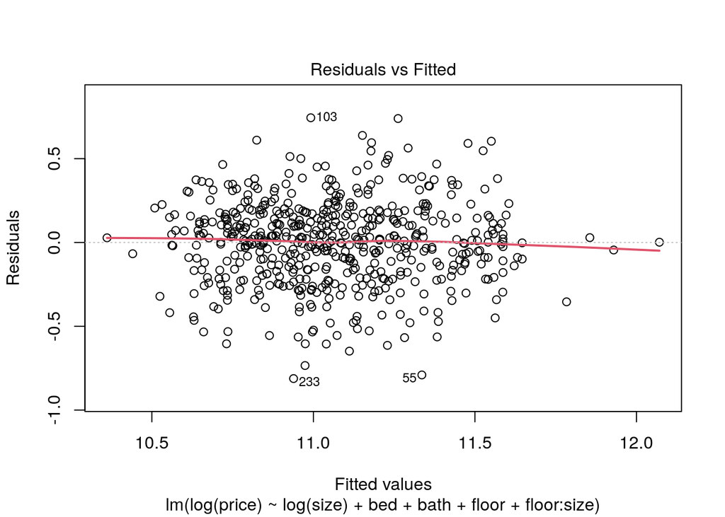

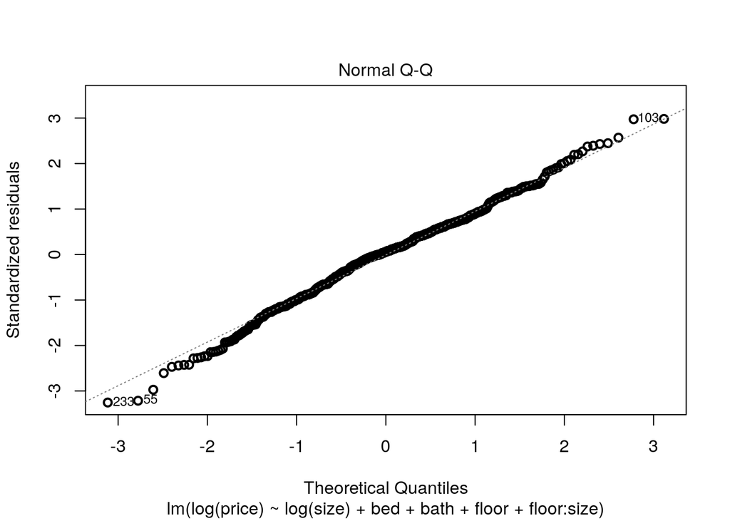

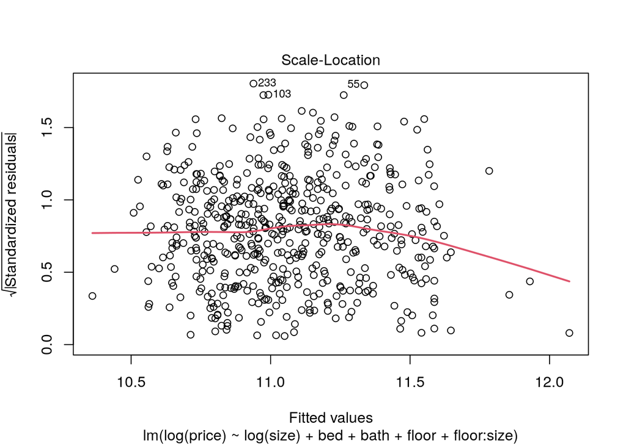

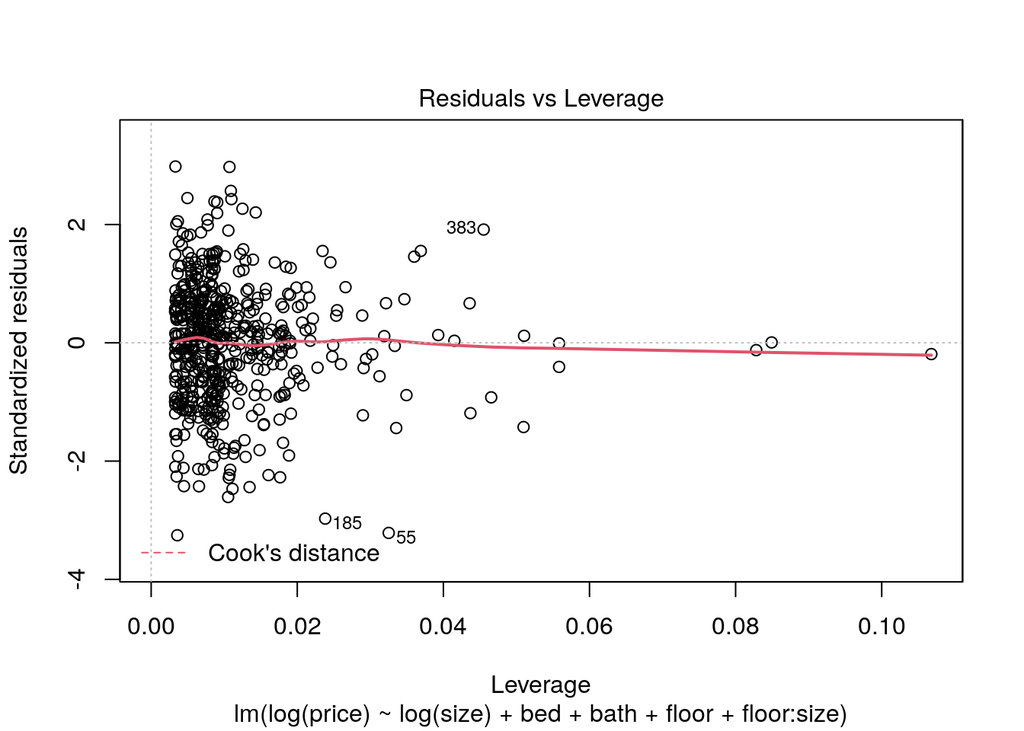

```r
plot(fit2, lwd = 2)
```

```r
AIC(fit, fit2)
```

```
##      df      AIC
## fit   6 47.35856
## fit2  7 43.51216
```

```r
BIC(fit, fit2)
```

```
##      df      BIC
## fit   6 73.17428
## fit2  7 73.63050
```

```r
calculateMSE(glm(log(price) ~ log(size) + bed + bath + floor, data=house), house)
```

```
## [1] "Training MSE: 0.0624669418293349"
## [1] "Cv estimate test MSE: 0.0636391730198946"
```

```r
calculateMSE(glm(log(price) ~ log(size) + bed + bath + floor + floor:size, data=house), house)
```

```
## [1] "Training MSE: 0.0618016332496612"
## [1] "Cv estimate test MSE: 0.0631361300617127"
```